# Player Scoring Analysis

#导入包与数据#

```r
library(ggplot2)
library(dplyr)
library(DMwR)
player_scoring <- read.csv("/Users/sun/Desktop/NBA/Seasons_Stats.csv",header=T, na.strings = "NA")
player <- read.csv("/Users/sun/Desktop/NBA/player_data.csv",header=T,na.strings = "NA")
#用每个变量的中位数进行缺失值填充
for(i in 7:53){
  player_scoring[which(is.na(player_scoring[,i])),i]<-median(player_scoring[,i],na.rm = T)
}
```

```r
summary(player_scoring)
```

```
##        X              Year                   Player           Pos
##  Min.   :    0   Min.   :1950                   :   67   PF     :4966
##  1st Qu.: 6172   1st Qu.:1981   Eddie Johnson   :   33   SG     :4811
##  Median :12345   Median :1996   Mike Dunleavy   :   32   C      :4759
##  Mean   :12345   Mean   :1993   Gerald Henderson:   29   SF     :4699
##  3rd Qu.:18518   3rd Qu.:2007   Nazr Mohammed   :   28   PG     :4648
##  Max.   :24690   Max.   :2017   Kevin Willis    :   27   G      : 139
##                  NA's   :67     (Other)         :24475   (Other): 669
##       Age              Tm              G               GS              MP
##  Min.   :18.00   TOT    : 2123   Min.   : 1.00   Min.   : 0.00   Min.   :   0
##  1st Qu.:24.00   NYK    : 1043   1st Qu.:27.00   1st Qu.: 1.00   1st Qu.: 354
##  Median :26.00   BOS    :  998   Median :58.00   Median : 8.00   Median :1053
##  Mean   :26.66   DET    :  917   Mean   :50.86   Mean   :19.51   Mean   :1206
##  3rd Qu.:29.00   PHI    :  871   3rd Qu.:75.00   3rd Qu.:26.00   3rd Qu.:1948
##  Max.   :44.00   LAL    :  834   Max.   :88.00   Max.   :83.00   Max.   :3882
##  NA's   :75      (Other):17905
##       PER              TS.             X3PAr             FTr
##  Min.   :-90.60   Min.   :0.0000   Min.   :0.0000   Min.   :0.0000
##  1st Qu.:  9.90   1st Qu.:0.4580   1st Qu.:0.0120   1st Qu.:0.2080
##  Median : 12.70   Median :0.5060   Median :0.0640   Median :0.2960
##  Mean   : 12.48   Mean   :0.4931   Mean   :0.1362   Mean   :0.3253
##  3rd Qu.: 15.50   3rd Qu.:0.5430   3rd Qu.:0.2150   3rd Qu.:0.4000
##  Max.   :129.10   Max.   :1.1360   Max.   :1.0000   Max.   :6.0000
##
##       ORB.              DRB.             TRB.              AST.
##  Min.   :  0.000   Min.   :  0.00   Min.   :  0.000   Min.   :  0.00
##  1st Qu.:  3.000   1st Qu.:  9.40   1st Qu.:  6.300   1st Qu.:  6.90
##  Median :  5.400   Median : 12.70   Median :  9.200   Median : 10.50
##  Mean   :  6.058   Mean   : 13.55   Mean   :  9.855   Mean   : 12.79
##  3rd Qu.:  8.300   3rd Qu.: 17.00   3rd Qu.: 12.900   3rd Qu.: 16.50
##  Max.   :100.000   Max.   :100.00   Max.   :100.000   Max.   :100.00
##
##       STL.             BLK.            TOV.            USG.
##  Min.   : 0.000   Min.   : 0.00   Min.   :  0.0   Min.   :  0.00
##  1st Qu.: 1.200   1st Qu.: 0.40   1st Qu.: 12.1   1st Qu.: 16.30
##  Median : 1.500   Median : 0.90   Median : 14.2   Median : 18.60
##  Mean   : 1.625   Mean   : 1.33   Mean   : 14.9   Mean   : 18.84
##  3rd Qu.: 2.000   3rd Qu.: 1.60   3rd Qu.: 16.6   3rd Qu.: 21.10
##  Max.   :24.200   Max.   :77.80   Max.   :100.0   Max.   :100.00
##
```

[output cut: 49 more lines]

```
##  Min.   :   0.0   Min.   :   0.0   Min.   :   0.0   Min.   :  0.00
##  1st Qu.:  44.0   1st Qu.:  52.5   1st Qu.:  19.0   1st Qu.: 12.00
##  Median : 106.0   Median : 159.0   Median :  68.0   Median : 29.00
##  Mean   : 140.7   Mean   : 223.6   Mean   : 114.7   Mean   : 38.18
##  3rd Qu.: 188.0   3rd Qu.: 318.0   3rd Qu.: 160.0   3rd Qu.: 53.00
##  Max.   :1111.0   Max.   :2149.0   Max.   :1164.0   Max.   :301.00
##
##       BLK              TOV               PF             PTS
##  Min.   :  0.00   Min.   :  0.00   Min.   :  0.0   Min.   :   0.0
##  1st Qu.:  4.00   1st Qu.: 26.00   1st Qu.: 39.0   1st Qu.: 107.0
##  Median : 11.00   Median : 55.00   Median :109.0   Median : 364.0
##  Mean   : 22.35   Mean   : 70.07   Mean   :116.3   Mean   : 509.7
##  3rd Qu.: 24.00   3rd Qu.: 95.00   3rd Qu.:182.0   3rd Qu.: 777.0
##  Max.   :456.00   Max.   :464.00   Max.   :386.0   Max.   :4029.0
##
```

```r
PTS <- as.data.frame(aggregate(player_scoring$PTS,by=list(player_scoring$Player),FUN=sum))
colnames(PTS) <- c("Name","pts")
PTS <- PTS[order(PTS$pts,decreasing=T),]
```

#1.变量解释和选择# **变量名与含义** 本数据统计了NBA67个赛季全体个人数据，包括得分，助攻，篮板等数据。下边介绍各项指标的含义即对应的变量名。 Player Efficiency Rating(PER):球员效率值，他是评判球员贡献的指标，PER在综合评判球员的成绩如投篮得分，发球，三分球，助攻，篮板，盖帽和抢断，以及负面结果，如投篮失误和个人犯规后统计该球员的成绩。得到其最重效率值。 Minutes Played(MP):每场比赛的上场时长 Total Rebounds/Percentage(TRB)(TRB.):总篮板球 Defensive Rebound/Rate(DRB)(DRB.):防守篮板，求全转换到防守方手中，进攻方球员投球未进，防守球员拿到球权，抢到球的球员记一个防守篮板球。 Offensive Rebound/Rate(ORB)(ORB.):进攻篮板,投篮不中，但本队队员将篮板抢回，重新获得进攻机会。抢到球的球员记一个进攻篮板球。

Field Goals made/attempted/percentage:(FG)(FGA)(FG.):投篮命中，除了罚球以外的投篮命中得分。 3-Point Field Goals/Attempts/Percentage(X3P)(3PA)(3P.):三分投篮命中 3-Point Attempt Rate(3PAr) 2-Point Field Goals/Attempts/Percentage(X2P)(X2PA)(X2P.):二分投篮命中 Effective Field Goal(eFG.):有效的投篮得分率 Free Throws/Attempts/Percentage(FT)(FTA)(FT.):罚球 True Shooting Rate(TS.) Assists/Assists Percentage(AST)(AST.):助攻 Steals/Steal Percentage(STL)(STL.): Blocks/Blocks Percentage(BLK)(BLK.): Turnovers/Turnover Percentage(TOV)(TOV.):犯规 Personal Fouls(PF): Points(PTS): Box Plus/Minus(BPM): Defensive Box Plus/Minus(DBPM): Offensive Box Plus/Minus(OBPM): Value Over Replacement(VORP): Win Shares Per 48 Minutes(WS/48): Win Shares(WS): Offensive Win Shares(OWS): Usage Percentage(USG.)

#得分最高的前20个球员进攻篮板效率和防守篮板效率的分布图

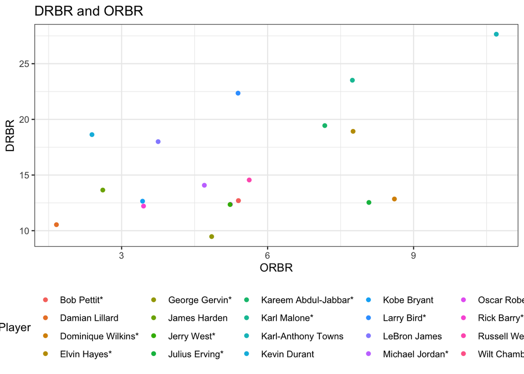

```r
theme_set(theme_bw())
ORB_DRB <-aggregate(player_scoring[,c("PTS","ORB.","DRB.")],by=list(player_scoring$Player),FUN=mean)
ORB_DRB <- ORB_DRB[order(ORB_DRB$PTS,decreasing=T),]
colnames(ORB_DRB) <- c("Player","PTS","ORBR","DRBR")
ggplot(ORB_DRB[1:20,],aes(x=ORBR,y=DRBR))+
  geom_point(aes(color=Player))+ theme(legend.position="bottom")+
  labs(title="DRBR and ORBR")
```

#构造控球变量： 个人单个赛季控球时长：是当一个队拿到控球权开始，到失去控球权结束的。每场比赛两队的控球机会是接近相等的。衡量两队的控球机会可以有效的评估个人成绩和队伍成绩。每队球员为了赢得比赛，需要在控球的时候拿到更多的分数。我们根据上述变量构造控球变量。 第一种公式为：公式中每次犯规，投篮命中，和罚球结束一次控球。 $Poss_t=(FG_t+\lambda FT_t)+\alpha [(FGA_t-FG_t)+\lambda(FTA_t-FT_t)-ORB_t]+(1-\alpha)DRB_o+TO_t$其中参数$\lambda$是结束控球的罚球所占比率，参数$\alpha$是一个0-1之间的参数。 通常将参数设置为$\alpha=1;\lambda=0.44$ 第二种公式，我们不规定$\alpha和\lambda$，而是直接用64季比赛结果与具体的控球时间做线性回归，$Poss_t=\beta_0+\beta_1 FGA_t+\beta_2(FGA_t-FG_t)+\beta_3 FTA_T+\beta_4(FTA_t-FT_t)+\beta_5 ORB_t+\beta_6 DRB_o+\beta_7 TO_t+\epsilon$ 资料表明，根据OLS回归预测的模型参数为：$R^2=0.9615$

```r
player_scoring$POSS <- 3.2258+0.964*player_scoring$FGA-0.3452*(player_scoring$FGA-player_scoring$FG)+0.4637*player_scoring$FTA-0.2073*(player_scoring$FT-player_scoring$FT)-0.6227*player_scoring$ORB+0.3643*player_scoring$DRB+0.9767*player_scoring$TOV
```

#数据可视化 1.按照PTS统计出历史上得分最高的球员，

```r
player_scoring[which(player_scoring$Player=="Kareem Abdul-Jabbar*"),c("Year","Player","Pos","Age","Tm")]
```

|  | Year | Player | Pos | Age | Tm |
| --- | --- | --- | --- | --- | --- |
| 2869 | 1970 | Kareem Abdul-Jabbar* | C | 22 | MIL |
| 3071 | 1971 | Kareem Abdul-Jabbar* | C | 23 | MIL |
| 3317 | 1972 | Kareem Abdul-Jabbar* | C | 24 | MIL |
| 3583 | 1973 | Kareem Abdul-Jabbar* | C | 25 | MIL |
| 3853 | 1974 | Kareem Abdul-Jabbar* | C | 26 | MIL |
| 4099 | 1975 | Kareem Abdul-Jabbar* | C | 27 | MIL |
| 4376 | 1976 | Kareem Abdul-Jabbar* | C | 28 | LAL |
| 4651 | 1977 | Kareem Abdul-Jabbar* | C | 29 | LAL |
| 5011 | 1978 | Kareem Abdul-Jabbar* | C | 30 | LAL |
| 5383 | 1979 | Kareem Abdul-Jabbar* | C | 31 | LAL |

[output cut: 10 more lines]

卡利姆·阿布杜尔·贾巴尔，1947年出生的职业运动员，司职中锋，绰号“天勾”，在1969年NBA选秀中于第1轮第1位以状元秀的身份被密沃尔基雄鹿队选中，新秀赛季当选NBA年度最佳新秀。1970-71赛季贾巴尔场均31.7），获得常规赛MVP以及NBA得分王称号，并率队获得NBA总冠军。1976年转投洛杉矶湖人队，与有“魔术师”之称的埃尔文·约翰逊成为湖人队的两大支柱，率领球队五次夺得NBA总冠军。

```r
player_scoring[which(player_scoring$Player=="Karl Malone*"),c("Year","Player","Pos","Age","Tm")]
```

|  | Year | Player | Pos | Age | Tm |
| --- | --- | --- | --- | --- | --- |
| 8123 | 1986 | Karl Malone* | PF | 22 | UTA |
| 8495 | 1987 | Karl Malone* | PF | 23 | UTA |
| 8895 | 1988 | Karl Malone* | PF | 24 | UTA |
| 9340 | 1989 | Karl Malone* | PF | 25 | UTA |
| 9796 | 1990 | Karl Malone* | PF | 26 | UTA |
| 10252 | 1991 | Karl Malone* | PF | 27 | UTA |
| 10705 | 1992 | Karl Malone* | PF | 28 | UTA |
| 11151 | 1993 | Karl Malone* | PF | 29 | UTA |
| 11642 | 1994 | Karl Malone* | PF | 30 | UTA |
| 12090 | 1995 | Karl Malone* | PF | 31 | UTA |

[output cut: 9 more lines]

卡尔·马龙（Karl Malone），司职大前锋，绰号“邮差”（The Mailman） 在1985年NBA选秀中，卡尔·马龙在首轮第13顺位被犹他爵士队选中，职业生涯的前18个赛季在犹他爵士队度过，并与约翰·斯托克顿组成的“黑白双煞”让爵士队成为一支劲旅，两人带领爵士队两次打入NBA总决赛，但是都未能夺得NBA总冠军，生涯最后一年加盟洛杉矶湖人队

```r
player_scoring[which(player_scoring$Player=="Wilt Chamberlain*"),c("Year","Player","Pos","Age","Tm")]
```

|  | Year | Player | Pos | Age | Tm |
| --- | --- | --- | --- | --- | --- |
| 1474 | 1960 | Wilt Chamberlain* | C | 23 | PHW |
| 1594 | 1961 | Wilt Chamberlain* | C | 24 | PHW |
| 1707 | 1962 | Wilt Chamberlain* | C | 25 | PHW |
| 1828 | 1963 | Wilt Chamberlain* | C | 26 | SFW |
| 1963 | 1964 | Wilt Chamberlain* | C | 27 | SFW |
| 2100 | 1965 | Wilt Chamberlain* | C | 28 | TOT |
| 2101 | 1965 | Wilt Chamberlain* | C | 28 | SFW |
| 2102 | 1965 | Wilt Chamberlain* | C | 28 | PHI |
| 2240 | 1966 | Wilt Chamberlain* | C | 29 | PHI |
| 2367 | 1967 | Wilt Chamberlain* | C | 30 | PHI |

[output cut: 6 more lines]

威尔特·张伯伦,司职中锋。曾效力于NBA费城/旧金山勇士队（现金州勇士队）、费城76人队以及洛杉矶湖人队；毕业于堪萨斯大学的他在NBA打球之前曾在哈林篮球队效力，之后被认为是NBA历史上具有统治力的球员之一。2次夺得NBA总冠军），4次荣膺NBA常规赛MVP，13次入选NBA全明星阵容，10次入选NBA最佳阵容，连续2次入选NBA最佳防守阵容一阵，连续7次荣膺NBA得分王，11次荣膺NBA篮板王，1968年荣膺NBA助攻王。

```r
player_scoring[which(player_scoring$Player=="Kobe Bryant"),c("Year","Player","Pos","Age","Tm")]
```

|  | Year | Player | Pos | Age | Tm |
| --- | --- | --- | --- | --- | --- |
| 12901 | 1997 | Kobe Bryant | SG | 18 | LAL |
| 13480 | 1998 | Kobe Bryant | SG | 19 | LAL |
| 14022 | 1999 | Kobe Bryant | SG | 20 | LAL |
| 14538 | 2000 | Kobe Bryant | SG | 21 | LAL |
| 15029 | 2001 | Kobe Bryant | SG | 22 | LAL |
| 15579 | 2002 | Kobe Bryant | SG | 23 | LAL |
| 16071 | 2003 | Kobe Bryant | SG | 24 | LAL |
| 16577 | 2004 | Kobe Bryant | SG | 25 | LAL |
| 17160 | 2005 | Kobe Bryant | SG | 26 | LAL |
| 17743 | 2006 | Kobe Bryant | SG | 27 | LAL |

[output cut: 10 more lines]

科比·比恩·布莱恩特,司职得分后卫/小前锋（锋卫摇摆人），绰号“黑曼巴”/“小飞侠”。 科比是前NBA球员乔·布莱恩特的儿子。在1996年NBA选秀中，科比于第1轮第13位被夏洛特黄蜂队选中，后被交易至洛杉矶湖人队，整个NBA生涯（1996年-2016年）都效力于洛杉矶湖人队。 科比的职业生涯随湖人队5夺NBA总冠军；荣膺1次常规赛MVP（2007-08赛季），2次总决赛MVP，4次全明星赛MVP；共18次入选NBA全明星阵容，15次入选NBA最佳阵容，12次入选NBA最佳防守阵容。

```r
player_scoring[which(player_scoring$Player=="Michael Jordan*"),c("Year","Player","Pos","Age","Tm")]
```

|  | Year | Player | Pos | Age | Tm |
| --- | --- | --- | --- | --- | --- |
| 7717 | 1985 | Michael Jordan* | SG | 21 | CHI |
| 8095 | 1986 | Michael Jordan* | SG | 22 | CHI |
| 8470 | 1987 | Michael Jordan* | SG | 23 | CHI |
| 8870 | 1988 | Michael Jordan* | SG | 24 | CHI |
| 9298 | 1989 | Michael Jordan* | SG | 25 | CHI |
| 9748 | 1990 | Michael Jordan* | SG | 26 | CHI |
| 10213 | 1991 | Michael Jordan* | SG | 27 | CHI |
| 10667 | 1992 | Michael Jordan* | SG | 28 | CHI |
| 11107 | 1993 | Michael Jordan* | SG | 29 | CHI |
| 12049 | 1995 | Michael Jordan* | SG | 31 | CHI |

[output cut: 5 more lines]

迈克尔·乔丹（Michael Jordan）司职得分后卫，绰号“飞人”（Air Jordan） [1] 。 迈克尔·乔丹在在1984年NBA选秀中于第1轮第3位被芝加哥公牛队选中，职业生涯曾效力于芝加哥公牛队以及华盛顿奇才队，新秀赛季当选NBA年度最佳新秀。1986-87赛季，乔丹场均得到37.1分，首次获得NBA得分王称号。1991-93赛季，乔丹连续2次荣膺常规赛MVP）和3次总决赛MVP

[figure not shown]

```r
PTS$Name <- factor(PTS$Name,levels=PTS$Name)
ggplot(PTS[6:20,],aes(x=Name,y=pts))+
  geom_bar(stat="identity", width=.5, fill="tomato3") +

labs(title="Top 20 Points Player In One's Life") +

theme(axis.text.x = element_text(angle=65, vjust=0.6))
```